# Question 1

Endogeneity does not necessarily lead to bad prediction performance on a training set, or even a holdour test set, if the test set is very similar to the training set. The main problem is we are overfitting the data in such a situation. The main problem arises when we use such a model to predict something that does not resemble the training set. The main benefit of using a method such as SLS is that it can improve the generalizability of the model. In a more causal sense, if we use 2SLS, we try to solve the endogeneity problem. When doing this, we generally end up getting a worse fit on the training data. However, the model we get is more likely to work well on scenarios and datasets that are different than ours.

# Qeustion 2

```r
library(data.table)
library(tidyverse)
library(dtplyr)
```

```r
card_colnames <- c("id",        "nearc2",    "nearc4",    "educ",      "age",       "fatheduc",  "motheduc",  "weight",
"momdad14",  "sinmom14",  "step14",    "reg661",    "reg662",    "reg663",    "reg664",    "reg665",
"reg666",    "reg667",    "reg668",    "reg669",    "south66",   "black",     "smsa",      "south",
"smsa66",    "wage",      "enroll",    "KWW",       "IQ",        "married",   "libcrd14",  "exper",
"lwage",     "expersq")

card <- read_fwf("./CARD.raw", na = c(".","NA"))

colnames(card) <- card_colnames
```

```r
head(card)
```

A tibble: 6 × 34

| id <dbl> | nearc2 <dbl> | nearc4 <dbl> | educ <dbl> | age <dbl> | fatheduc <dbl> | motheduc <dbl> | weight <chr> | momdad14 <dbl> | sinmom14 <dbl> | ⋯ | smsa66 <dbl> | wage <dbl> | enroll <dbl> | KWW <dbl> | IQ <dbl> | married <dbl> | libcrd14 <dbl> | exper <dbl> | lwage <dbl> | expersq <dbl> |
| --- | --- | --- | --- | --- | --- | --- | --- | --- | --- | --- | --- | --- | --- | --- | --- | --- | --- | --- | --- | --- |
| 2 | 0 | 0 | 7 | 29 | NA | NA | 158413 | 1 | 0 | ⋯ | 1 | 548 | 0 | 15 | NA | 1 | 0 | 16 | 6.306275 | 256 |
| 3 | 0 | 0 | 12 | 27 | 8 | 8 | 380166 | 1 | 0 | ⋯ | 1 | 481 | 0 | 35 | 93 | 1 | 1 | 9 | 6.175867 | 81 |
| 4 | 0 | 0 | 12 | 34 | 14 | 12 | 367470 | 1 | 0 | ⋯ | 1 | 721 | 0 | 42 | 103 | 1 | 1 | 16 | 6.580639 | 256 |
| 5 | 1 | 1 | 11 | 27 | 11 | 12 | 380166 | 1 | 0 | ⋯ | 1 | 250 | 0 | 25 | 88 | 1 | 1 | 10 | 5.521461 | 100 |
| 6 | 1 | 1 | 12 | 34 | 8 | 7 | 367470 | 1 | 0 | ⋯ | 1 | 729 | 0 | 34 | 108 | 1 | 0 | 16 | 6.591674 | 256 |
| 7 | 1 | 1 | 12 | 26 | 9 | 12 | 380166 | 1 | 0 | ⋯ | 1 | 500 | 0 | 38 | 85 | 1 | 1 | 8 | 6.214608 | 64 |

## a

```r
ols_card <- lm(
    log(wage) ~
        educ +
        reg661 +
        reg662 +
        reg663 +
        reg664 +
        reg665 +
        reg666 +
        reg667 +
        reg668 +
        black +
        smsa +
        south +
        smsa66 +
        exper +
        expersq,
    data = card
)
```

### homoskedastic

```r
summary(ols_card)$coefficients %>% round(2)
```

A matrix: 16 × 4 of type dbl

|  | Estimate | Std. Error | t value | Pr(>\|t\|) |
| --- | --- | --- | --- | --- |
| (Intercept) | 4.74 | 0.07 | 66.26 | 0.00 |
| educ | 0.07 | 0.00 | 21.35 | 0.00 |
| reg661 | -0.12 | 0.04 | -3.05 | 0.00 |
| reg662 | -0.02 | 0.03 | -0.79 | 0.43 |
| reg663 | 0.03 | 0.03 | 0.95 | 0.34 |
| reg664 | -0.06 | 0.04 | -1.78 | 0.08 |
| reg665 | 0.01 | 0.04 | 0.26 | 0.79 |
| reg666 | 0.02 | 0.04 | 0.55 | 0.58 |
| reg667 | 0.00 | 0.04 | -0.01 | 0.99 |
| reg668 | -0.18 | 0.05 | -3.78 | 0.00 |
| black | -0.20 | 0.02 | -10.91 | 0.00 |
| smsa | 0.14 | 0.02 | 6.79 | 0.00 |
| south | -0.15 | 0.03 | -5.69 | 0.00 |
| smsa66 | 0.03 | 0.02 | 1.35 | 0.18 |
| exper | 0.08 | 0.01 | 12.81 | 0.00 |
| expersq | 0.00 | 0.00 | -7.22 | 0.00 |

### heteroskedasticity consistent

```r
library(lmtest)
library(sandwich)
coeftest(ols_card, vcov = vcovHC(old_card, type = "HC0"))[,] %>% round(2)
```

A matrix: 16 × 4 of type dbl

[output not shown]

### Explanation

There was no substantial difference between the two estimates. We would be better of using the heteroskedasticity consistent methods if there was a correlation between the variance of the error term and the predictors.

## b

```r
educ_card <- lm(
    educ ~
        nearc4 +
        reg661 +
        reg662 +
        reg663 +
        reg664 +
        reg665 +
        reg666 +
        reg667 +
        reg668 +
        black +
        smsa +
        south +
        smsa66 +
        exper +
        expersq,
    data = card
)
```

### homoskedastic

```r
summary(educ_card)$coefficients %>% round(2)
```

A matrix: 16 × 4 of type dbl

|  | Estimate | Std. Error | t value | Pr(>\|t\|) |
| --- | --- | --- | --- | --- |
| (Intercept) | 16.85 | 0.21 | 79.80 | 0.00 |
| nearc4 | 0.32 | 0.09 | 3.64 | 0.00 |
| reg661 | -0.21 | 0.20 | -1.04 | 0.30 |
| reg662 | -0.29 | 0.15 | -1.96 | 0.05 |
| reg663 | -0.24 | 0.14 | -1.67 | 0.10 |
| reg664 | -0.09 | 0.19 | -0.50 | 0.62 |
| reg665 | -0.48 | 0.19 | -2.57 | 0.01 |
| reg666 | -0.51 | 0.21 | -2.45 | 0.01 |
| reg667 | -0.43 | 0.21 | -2.08 | 0.04 |
| reg668 | 0.31 | 0.24 | 1.30 | 0.19 |
| black | -0.94 | 0.09 | -9.98 | 0.00 |
| smsa | 0.40 | 0.10 | 3.84 | 0.00 |
| south | -0.05 | 0.14 | -0.38 | 0.70 |
| smsa66 | 0.03 | 0.11 | 0.24 | 0.81 |
| exper | -0.41 | 0.03 | -12.24 | 0.00 |
| expersq | 0.00 | 0.00 | 0.53 | 0.60 |

### heteroskedasticity consistent

```r
coeftest(educ_card, vcov = vcovHC(educ_card, type = "HC0"))[,] %>% round(2)
```

A matrix: 16 × 4 of type dbl

|  | Estimate | Std. Error | t value | Pr(>\|t\|) |
| --- | --- | --- | --- | --- |
| (Intercept) | 16.85 | 0.19 | 90.55 | 0.00 |
| nearc4 | 0.32 | 0.08 | 3.77 | 0.00 |
| reg661 | -0.21 | 0.20 | -1.06 | 0.29 |
| reg662 | -0.29 | 0.15 | -1.91 | 0.06 |
| reg663 | -0.24 | 0.14 | -1.67 | 0.10 |
| reg664 | -0.09 | 0.18 | -0.52 | 0.60 |
| reg665 | -0.48 | 0.19 | -2.48 | 0.01 |
| reg666 | -0.51 | 0.21 | -2.46 | 0.01 |
| reg667 | -0.43 | 0.21 | -2.03 | 0.04 |
| reg668 | 0.31 | 0.23 | 1.35 | 0.18 |
| black | -0.94 | 0.09 | -10.14 | 0.00 |
| smsa | 0.40 | 0.11 | 3.63 | 0.00 |
| south | -0.05 | 0.14 | -0.36 | 0.72 |
| smsa66 | 0.03 | 0.11 | 0.23 | 0.82 |
| exper | -0.41 | 0.03 | -12.90 | 0.00 |
| expersq | 0.00 | 0.00 | 0.51 | 0.61 |

### explanation

Again, there was no sustantial difference between the homo and heteroskedasticity consistent resutls. We did find a statistically significant correlation beween nearc4 and educ.

## c

```r
library(ivreg)

iv_card <- ivreg(
    log(wage) ~
    reg661 +
    reg662 +
    reg663 +
    reg664 +
    reg665 +
    reg666 +
    reg667 +
    reg668 +
    black +
    smsa +
    south +
    smsa66 +
    exper +
    expersq|
    educ | nearc4,
    data = card
)
```

```r
summary(iv_card, vcov = sandwich)
```

```
Call:
ivreg(formula = log(wage) ~ reg661 + reg662 + reg663 + reg664 +
    reg665 + reg666 + reg667 + reg668 + black + smsa + south +
    smsa66 + exper + expersq | educ | nearc4, data = card)

Residuals:
     Min       1Q   Median       3Q      Max
-1.83164 -0.24075  0.02429  0.25208  1.42760

Coefficients:
              Estimate Std. Error t value Pr(>|t|)
(Intercept)  3.7739653  0.9174053   4.114 4.00e-05 ***
educ         0.1315038  0.0539995   2.435 0.014938 *
reg661      -0.1078142  0.0409668  -2.632 0.008538 **
reg662      -0.0070465  0.0336994  -0.209 0.834387
reg663       0.0404445  0.0325208   1.244 0.213725
reg664      -0.0579171  0.0392106  -1.477 0.139759
reg665       0.0384576  0.0494675   0.777 0.436965
reg666       0.0550887  0.0521309   1.057 0.290716
reg667       0.0267580  0.0501066   0.534 0.593367
reg668      -0.1908912  0.0506897  -3.766 0.000169 ***
black       -0.1467758  0.0523622  -2.803 0.005094 **
smsa         0.1118083  0.0310619   3.600 0.000324 ***
south       -0.1446715  0.0290653  -4.977 6.81e-07 ***
smsa66       0.0185311  0.0205103   0.904 0.366333
exper        0.1082711  0.0233466   4.638 3.68e-06 ***
expersq     -0.0023349  0.0003478  -6.713 2.27e-11 ***

Diagnostic tests:
                  df1  df2 statistic  p-value
Weak instruments    1 2994    14.214 0.000166 ***
Wu-Hausman          1 2993     1.219 0.269649
Sargan              0   NA        NA       NA
---
Signif. codes:  0 ‘***’ 0.001 ‘**’ 0.01 ‘*’ 0.05 ‘.’ 0.1 ‘ ’ 1

Residual standard error: 0.3883 on 2994 degrees of freedom
Multiple R-Squared: 0.2382,	Adjusted R-squared: 0.2343
Wald test: 56.06 on 15 and 2994 DF,  p-value: < 2.2e-16
```

```r
confint(iv_card, vcov = sandwich) %>% round(2)
```

A matrix: 16 × 2 of type dbl

|  | 2.5 % | 97.5 % |
| --- | --- | --- |
| (Intercept) | 1.98 | 5.57 |
| educ | 0.03 | 0.24 |
| reg661 | -0.19 | -0.03 |
| reg662 | -0.07 | 0.06 |
| reg663 | -0.02 | 0.10 |
| reg664 | -0.13 | 0.02 |
| reg665 | -0.06 | 0.14 |
| reg666 | -0.05 | 0.16 |
| reg667 | -0.07 | 0.13 |
| reg668 | -0.29 | -0.09 |
| black | -0.25 | -0.04 |
| smsa | 0.05 | 0.17 |
| south | -0.20 | -0.09 |
| smsa66 | -0.02 | 0.06 |
| exper | 0.06 | 0.15 |
| expersq | 0.00 | 0.00 |

```r
confint(ols_card, vcov = sandwich) %>% round(2)
```

A matrix: 16 × 2 of type dbl

|  | 2.5 % | 97.5 % |
| --- | --- | --- |
| (Intercept) | 4.60 | 4.88 |
| educ | 0.07 | 0.08 |
| reg661 | -0.19 | -0.04 |
| reg662 | -0.08 | 0.03 |
| reg663 | -0.03 | 0.08 |
| reg664 | -0.13 | 0.01 |
| reg665 | -0.06 | 0.08 |
| reg666 | -0.06 | 0.10 |
| reg667 | -0.08 | 0.08 |
| reg668 | -0.27 | -0.08 |
| black | -0.23 | -0.16 |
| smsa | 0.10 | 0.18 |
| south | -0.20 | -0.10 |
| smsa66 | -0.01 | 0.06 |
| exper | 0.07 | 0.10 |
| expersq | 0.00 | 0.00 |

### explanation

In the original regression the estimate was 0.07, but in the IV, the estimate was 0.13. This means that the endogeneity was negatively biasing our estimate. Both estimates are significantly non-zero. The confidence interval of IV is much wider.

## d

```r
educ_card <- lm(
    educ ~
        nearc4 +
        nearc2 +
        reg661 +
        reg662 +
        reg663 +
        reg664 +
        reg665 +
        reg666 +
        reg667 +
        reg668 +
        black +
        smsa +
        south +
        smsa66 +
        exper +
        expersq,
    data = card
)
```

```r
coeftest(educ_card, vcov = vcovHC(educ_card, type = "HC0"))[, ] %>% round(2)
```

A matrix: 17 × 4 of type dbl

|  | Estimate | Std. Error | t value | Pr(>\|t\|) |
| --- | --- | --- | --- | --- |
| (Intercept) | 16.77 | 0.19 | 86.69 | 0.00 |
| nearc4 | 0.32 | 0.08 | 3.78 | 0.00 |
| nearc2 | 0.12 | 0.08 | 1.59 | 0.11 |
| reg661 | -0.17 | 0.20 | -0.84 | 0.40 |
| reg662 | -0.27 | 0.15 | -1.77 | 0.08 |
| reg663 | -0.19 | 0.15 | -1.30 | 0.19 |
| reg664 | -0.04 | 0.18 | -0.21 | 0.84 |
| reg665 | -0.44 | 0.20 | -2.22 | 0.03 |
| reg666 | -0.50 | 0.21 | -2.40 | 0.02 |
| reg667 | -0.38 | 0.21 | -1.77 | 0.08 |
| reg668 | 0.38 | 0.24 | 1.61 | 0.11 |
| black | -0.95 | 0.09 | -10.24 | 0.00 |
| smsa | 0.40 | 0.11 | 3.62 | 0.00 |
| south | -0.04 | 0.14 | -0.30 | 0.77 |
| smsa66 | 0.00 | 0.11 | 0.00 | 1.00 |
| exper | -0.41 | 0.03 | -12.92 | 0.00 |
| expersq | 0.00 | 0.00 | 0.50 | 0.62 |

```r
library(ivreg)

iv_card <- ivreg(
    log(wage) ~
        reg661 +
        reg662 +
        reg663 +
        reg664 +
        reg665 +
        reg666 +
        reg667 +
        reg668 +
        black +
        smsa +
        south +
        smsa66 +
        exper +
        expersq |
        educ | nearc4 + nearc2,
    data = card
)
```

```r
summary(iv_card, vcov = sandwich)
```

```
Call:
ivreg(formula = log(wage) ~ reg661 + reg662 + reg663 + reg664 +
    reg665 + reg666 + reg667 + reg668 + black + smsa + south +
    smsa66 + exper + expersq | educ | nearc4 + nearc2, data = card)

Residuals:
     Min       1Q   Median       3Q      Max
-1.93841 -0.25068  0.01932  0.26519  1.46998

Coefficients:
              Estimate Std. Error t value Pr(>|t|)
(Intercept)  3.3396868  0.8909170   3.749 0.000181 ***
educ         0.1570594  0.0524127   2.997 0.002753 **
reg661      -0.1029760  0.0425755  -2.419 0.015637 *
reg662      -0.0002287  0.0345230  -0.007 0.994716
reg663       0.0469556  0.0335252   1.401 0.161435
reg664      -0.0554084  0.0408927  -1.355 0.175529
reg665       0.0515041  0.0506274   1.017 0.309085
reg666       0.0699968  0.0534531   1.309 0.190466
reg667       0.0390596  0.0514309   0.759 0.447640
reg668      -0.1980371  0.0522335  -3.791 0.000153 ***
black       -0.1232778  0.0514904  -2.394 0.016718 *
smsa         0.1007530  0.0313621   3.213 0.001329 **
south       -0.1431945  0.0301873  -4.744 2.20e-06 ***
smsa66       0.0150626  0.0211120   0.713 0.475616
exper        0.1188149  0.0228905   5.191 2.24e-07 ***
expersq     -0.0023565  0.0003674  -6.414 1.64e-10 ***

Diagnostic tests:
                  df1  df2 statistic  p-value
Weak instruments    2 2993     8.366 0.000238 ***
Wu-Hausman          1 2993     2.978 0.084509 .
Sargan              1   NA     1.248 0.263905
---
Signif. codes:  0 ‘***’ 0.001 ‘**’ 0.01 ‘*’ 0.05 ‘.’ 0.1 ‘ ’ 1

Residual standard error: 0.4053 on 2994 degrees of freedom
Multiple R-Squared: 0.1702,	Adjusted R-squared: 0.166
Wald test: 51.65 on 15 and 2994 DF,  p-value: < 2.2e-16
```

### explanation

The results of the first stage model show that nearc2 has a weaker relationship with education compared to nearc4. The results of the IV in this case leads to a stronger relationship between educ and wage, compared both to the OLS estimate and the IV with only nearc4.

## e

```r
iq_card <- lm(
    IQ ~
        nearc4,
    data = card
)
```

```r
coeftest(iq_card, vcov = vcovHC(iq_card, type = "HC0"))[, ] %>% round(2)
```

A matrix: 2 × 4 of type dbl

|  | Estimate | Std. Error | t value | Pr(>\|t\|) |
| --- | --- | --- | --- | --- |
| (Intercept) | 100.61 | 0.63 | 158.99 | 0 |
| nearc4 | 2.60 | 0.75 | 3.47 | 0 |

### explanation

The result suggests that people living near a 4 year college tend to have a higher IQ.

## f

```r
IQ_multi_card <- lm(
    IQ ~
        nearc4 +
        reg661 +
        reg662 +
        reg669 +
        smsa66,
    data = card
)
```

```r
coeftest(IQ_multi_card, vcov = vcovHC(IQ_multi_card, type = "HC0"))[, ] %>% round(2)
```

A matrix: 6 × 4 of type dbl

|  | Estimate | Std. Error | t value | Pr(>\|t\|) |
| --- | --- | --- | --- | --- |
| (Intercept) | 99.38 | 0.71 | 139.50 | 0.00 |
| nearc4 | 0.87 | 0.82 | 1.06 | 0.29 |
| reg661 | 4.77 | 1.42 | 3.36 | 0.00 |
| reg662 | 5.81 | 0.87 | 6.70 | 0.00 |
| reg669 | 1.84 | 1.14 | 1.62 | 0.11 |
| smsa66 | 1.35 | 0.79 | 1.72 | 0.09 |

### explanation

nearc4 is not a statistically significant predictor anymore. This means that the results were counfounded by the added variables. In more practical words, this means that people living in these regions happened to also live near 4 year colleges, for example because these regions were bigger cities, and also people living in bigger cities happenned to have higher IQs.

# Question 3

```r
library(MASS)


simulator_xy <- function(n_sim = 1000 , beta = 1, pi_list = c(0, 0.25, 1, 2), n = 100){

    z <- rnorm(n, 0, 1)
    uv <- mvrnorm(n,
        mu = c(0, 0),
        Sigma = matrix(c(1, 0.9, 0.9, 1), nrow = 2)
    )
    u <- uv[, 1]
    v <- uv[, 2]

    result <- data.table()
    for (pi in pi_list){
        for (i in 1:n_sim) {
            z <- rnorm(n, 0, 1)
            uv <- mvrnorm(n,
                mu = c(0, 0),
                Sigma = matrix(c(1, 0.9, 0.9, 1), nrow = 2)
            )
            u <- uv[, 1]
            v <- uv[, 2]

            x <- z * pi + v
            y <- x * beta + u

            stage_1_ols <- lm(x ~ z)
            x_pred <- predict(stage_1_ols)
            stage_2_iv <- lm(y ~ x_pred)

            stage_1_t_stat <- summary(stage_1_ols)$coefficients[2, 3]
            stage_1_p_value <- summary(stage_1_ols)$coefficients[2, 4]
            stage_2_t_stats <- summary(stage_2_iv)$coefficients[2, 3]
            stage_2_p_value <- summary(stage_2_iv)$coefficients[2, 4]
            stage_1_coef <- summary(stage_1_ols)$coefficients[2, 1]
            stage_2_coef <- summary(stage_2_iv)$coefficients[2, 1]
            stage_2_se <- summary(stage_2_iv)$coefficients[2, 2]

            result = rbind(result, data.table(
                pi = pi,
                stage_1_t_stat = stage_1_t_stat,
                stage_1_p_value = stage_1_p_value,
                stage_2_t_stats = stage_2_t_stats,
                stage_2_p_value = stage_2_p_value,
                stage_1_coef = stage_1_coef,
                stage_2_coef = stage_2_coef,
                stage_2_se = stage_2_se
            ))
        }
    }
    return(result)
}

result <- simulator_xy(n_sim = 1000 , beta = 1, pi_list = c(0, 0.25, 1, 2))
```

```r
head(result)
```

A data.table: 6 × 8

| pi <dbl> | stage_1_t_stat <dbl> | stage_1_p_value <dbl> | stage_2_t_stats <dbl> | stage_2_p_value <dbl> | stage_1_coef <dbl> | stage_2_coef <dbl> | stage_2_se <dbl> |
| --- | --- | --- | --- | --- | --- | --- | --- |
| 0 | 0.09087531 | 0.9277772 | -0.003753677 | 0.9970126 | 0.008293969 | -0.07919728 | 21.098584 |
| 0 | -0.84280314 | 0.4013908 | 0.320131527 | 0.7495502 | -0.071988366 | 0.75781628 | 2.367203 |
| 0 | -0.65351079 | 0.5149575 | 0.453620313 | 0.6511050 | -0.063640872 | 1.34916572 | 2.974218 |
| 0 | 0.04314344 | 0.9656750 | 0.399395306 | 0.6904710 | 0.004404761 | 17.91855190 | 44.864202 |
| 0 | -0.52971167 | 0.5975099 | 0.636454292 | 0.5259641 | -0.057790004 | 2.27622429 | 3.576414 |
| 0 | -0.07391714 | 0.9412270 | -0.286444492 | 0.7751424 | -0.006281663 | -8.00766309 | 27.955375 |

## a

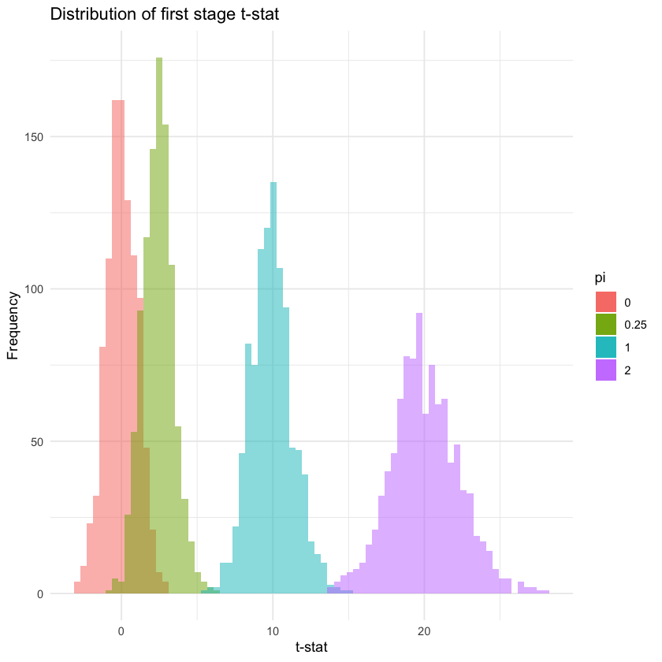

```r
result[, pi := factor(pi)]

# distribution of first stage t-stat grouped by pi
ggplot(data = result) +
    geom_histogram(data = result[pi == 0], aes(x = stage_1_t_stat, fill=pi), bins = 75, alpha = 0.5) +
    geom_histogram(data = result[pi == 0.25], aes(x = stage_1_t_stat, fill=pi), bins = 75, alpha = 0.5) +
    geom_histogram(data = result[pi == 1], aes(x = stage_1_t_stat, fill=pi), bins = 75, alpha = 0.5) +
    geom_histogram(data = result[pi == 2], aes(x = stage_1_t_stat, fill=pi), bins = 75, alpha = 0.5) +
    theme_minimal() +
    labs(
        title = "Distribution of first stage t-stat",
        x = "t-stat",
        y = "Frequency"
    )
```

```r
# simulatiobn rejection frequency of pi = 0 in each case
result[, .(stage_1_reject = sum(abs(stage_1_t_stat) > 1.96)/1000), keyby = pi]
```

A data.table: 4 × 2

| pi <fct> | stage_1_reject <dbl> |
| --- | --- |
| 0 | 0.056 |
| 0.25 | 0.671 |
| 1 | 1.000 |
| 2 | 1.000 |

### explanation

In all cases, the T-stats are normally distributed, with higher pi values, we get higher means and higher variances for these distributions. When we use pi=0, we reject the null hypothesis around 5% of the time, as we would expect from a normal distribution with mean zero and variance 1. when we use pi=0.25 we reject it around 70% of the time. In cases of pi=1 or 2, we reject the null hypothesis nearly 100% of the time.

## b

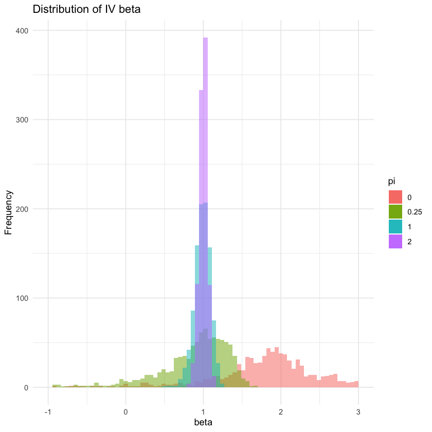

```r
# distribution of IV beta
ggplot() +
    geom_histogram(data = result[pi == 0], aes(x = stage_2_coef, fill=pi), bins = 75, alpha = 0.5) +
    geom_histogram(data = result[pi == 0.25], aes(x = stage_2_coef, fill=pi), bins = 75, alpha = 0.5) +
    geom_histogram(data = result[pi == 1], aes(x = stage_2_coef, fill=pi), bins = 75, alpha = 0.5) +
    geom_histogram(data = result[pi == 2], aes(x = stage_2_coef, fill=pi), bins = 75, alpha = 0.5) +
    theme_minimal() +
    labs(
        title = "Distribution of IV beta",
        x = "beta",
        y = "Frequency"
    ) +
    xlim(c(-1, 3))
```

```r
# finding 5% rejection of IV beta
result[, `:=`(beta_upper = stage_2_coef + 1.96 * stage_2_se, beta_lower = stage_2_coef - 1.96 * stage_2_se)]
result[, .(beta_equals_1_reject = 1 - mean(beta_lower < 1 & beta_upper > 1)), keyby = pi]
```

A data.table: 4 × 2

| pi <fct> | beta_equals_1_reject <dbl> |
| --- | --- |
| 0 | 0.000 |
| 0.25 | 0.001 |
| 1 | 0.001 |
| 2 | 0.000 |

```r
# mean of IV beta
result[, .(mean = mean(stage_2_coef)), keyby = pi]
#median of IV beta
result[, .(median = median(stage_2_coef)), keyby = pi]
```

A data.table: 4 × 2

| pi <fct> | mean <dbl> |
| --- | --- |
| 0 | 1.7920847 |
| 0.25 | 0.9359848 |
| 1 | 0.9852111 |
| 2 | 0.9990991 |

A data.table: 4 × 2

| pi <fct> | median <dbl> |
| --- | --- |
| 0 | 1.9049147 |
| 0.25 | 0.9689817 |
| 1 | 0.9948681 |
| 2 | 1.0030035 |

## c

```r
# only including cases where stage 1 is significant
stage_1_significat <- result[stage_1_p_value < 0.05]
stage_1_significat[, `:=`(beta_upper = stage_2_coef + 1.96 * stage_2_se, beta_lower = stage_2_coef - 1.96 * stage_2_se)]
stage_1_significat[, .(beta_equals_1_reject = 1-mean(beta_lower < 1 & beta_upper > 1)), keyby = pi]
stage_1_significat[, .(mean = mean(stage_2_coef)), keyby = pi]
stage_1_significat[, .(median = median(stage_2_coef)), keyby = pi]
```

A data.table: 4 × 2

[output not shown]

A data.table: 4 × 2

| pi <fct> | mean <dbl> |
| --- | --- |
| 0 | 1.9280883 |
| 0.25 | 1.0928021 |
| 1 | 0.9852111 |
| 2 | 0.9990991 |

A data.table: 4 × 2

| pi <fct> | median <dbl> |
| --- | --- |
| 0 | 1.9270204 |
| 0.25 | 1.1053759 |
| 1 | 0.9948681 |
| 2 | 1.0030035 |

## d

```r
# only including cases where stage 1 is significant
stage_1_f_significat <- result[stage_1_t_stat^2 > 10]
stage_1_f_significat[, `:=`(beta_upper = stage_2_coef + 1.96 * stage_2_se,
 beta_lower = stage_2_coef - 1.96 * stage_2_se)]
stage_1_f_significat[, .(beta_equals_1_reject = 1-mean(beta_lower < 1 & beta_upper > 1)), keyby = pi]
stage_1_f_significat[, .(mean = mean(stage_2_coef)), keyby = pi]
stage_1_f_significat[, .(median = median(stage_2_coef)), keyby = pi]
```

A data.table: 3 × 2

| pi <fct> | beta_equals_1_reject <dbl> |
| --- | --- |
| 0.25 | 0.004651163 |
| 1 | 0.001000000 |
| 2 | 0.000000000 |

A data.table: 3 × 2

| pi <fct> | mean <dbl> |
| --- | --- |
| 0.25 | 1.2879864 |
| 1 | 0.9852111 |
| 2 | 0.9990991 |

A data.table: 3 × 2

| pi <fct> | median <dbl> |
| --- | --- |
| 0.25 | 1.3077530 |
| 1 | 0.9948681 |
| 2 | 1.0030035 |